# Tema 1 - Probabilidad

## Probabilidades Básicas

## Definiciones básicas

Experimento aleatorio: experimento que repetido en las mismas condiciones puede dar resultados diferentes, pero que a largo plazo son predecibles.

Espacio muestral: el conjunto \(\Omega\) formado por todos los sucesos elementales del experimento aleatorio.

Suceso : Cualquier subconjunto del espacio muestral.

Alguno sucesos notables que merece la pena nombrar son:

- Suceso seguro o cierto: \(\Omega\)
- Suceso imposible o vacio: \(\emptyset\)
- Partes de un conjunto: \(\mathcal{P}(\Omega)\): conjunto de todos los sucesos del experimento aleatorio (es decir, el conjunto de todos los subconjuntos de \(\Omega\))

## Operaciones con sucesos

Si tenemos dos sucesos \(A,B\subseteq \Omega\), podemos definir:

- \(\Omega\): *suceso* total o *seguro*.
- \(\emptyset\): suceso *vacío* o *imposible*.
- \(A\cup B\): suceso *unión*; el que ocurre si sucede \(A\) o \(B\).
- \(A\cap B\): suceso *intersección*; el que ocurre si sucede \(A\) y \(B\).
- \(A^c\): suceso *complementario* el que sucede si NO sucede \(A\).
- \(A- B=A\cap B^c\): suceso *diferencia*, que acontece si sucede \(A\) y NO sucede \(B\).

Sucesos incompatibles: \(A\) y \(B\) son *incompatibles* (o *disjuntos*) cuando \(A\cap B=\emptyset\).

## Propiedades

Conmutativas:

\[A\cup B=B\cup A, \quad A\cap B=B\cap A\]

Asociativas:

\[A\cup(B\cup C)=(A\cup B)\cup C, \quad A\cap(B\cap C)=(A\cap B)\cap C\]

Distributivas:

\[A\cap(B\cup C)=(A\cap B)\cup (A\cap C), \quad A\cup(B\cap C)=(A\cup B)\cap (A\cup C)\]

## Propiedades

Complementario del complementario \[(A^c)^c=A\]

Leyes de De Morgan

\[(A\cup B)^c=A^c\cap B^c\]

\[(A\cap B)^c=A^c\cup B^c\]

## Definición de probabilidad

Sea \(\Omega\) el espacio muestral de un experimento aleatorio. Supongamos que el número de posibles resultados, por el momento, es finito.

Una probabilidad sobre \(\Omega\) es una aplicación \(P:\mathcal{P}(\Omega)\to [0,1]\) con las siguientes propiedades:

1. \(0\leq P(A)\leq 1\), para todo suceso \(A\).
2. \(P(\Omega)=1\).
3. Si \(\{A_1,A_2,\ldots,A_n\}\) son sucesos disjuntos dos a dos, entonces

\[ P(A_1\cup A_2\cup \cdots \cup A_n)=P(A_1)+P(A_2)+\cdots +P(A_n) \]

Si \(a\in \Omega\) es un suceso elemental cometeremos el abuso de notación de poner \(P(a)\) en lugar de \(P(\{a\})\)

## Propiedades

Propiedades básicas de la probabilidad

- \(P(\emptyset)=0\).
- \(P(A-B)=P(A)-P(A\cap B)\).

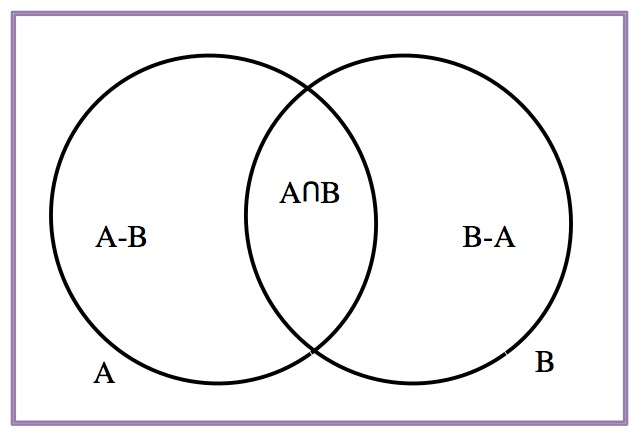

- Si \(B\subseteq A\), entonces \(0\leq P(B)\leq P(A)\).
- \(P(A^c)=1-P(A)\).

## Propiedades

- \(P(A\cup B)=P(A)+P(B)-P(A\cap B)\)

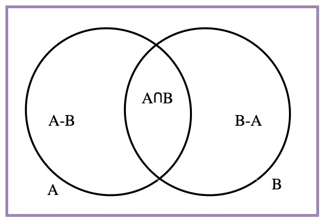

## Propiedades

- \[\begin{eqnarray*} P(A\cup B\cup C)&=&P(A)+P(B)+P(C) \\ &&-P(A\cap B)-P(A\cap C)-P(B\cap C) +P(A\cap B\cap C) \end{eqnarray*}\]

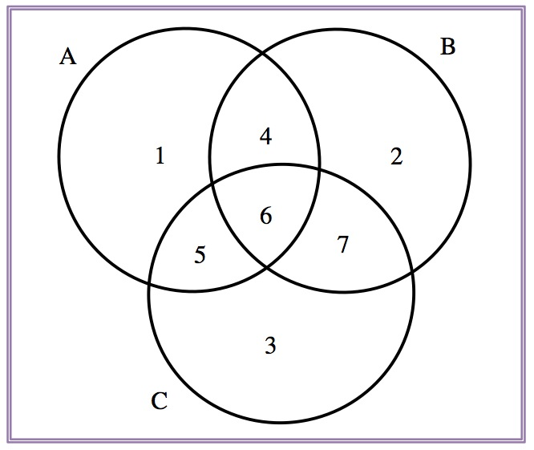

\[P(A\cup B\cup C)=P(1)+P(2)+P(3)+P(4)+P(5)+P(6)+P(7).\]

## Propiedades

- Si \(A=\{a_1,a_2,\ldots,a_k\}\), entonces \[ P(A)=P(a_1)+P(a_2)+\cdots+P(a_k). \]
- Si todos los sucesos elementales tienen la misma probabilidad, \[ P(A)=\frac{|A|}{|\Omega|}\Big(=\frac{\mbox{casos favorables}}{\mbox{casos posibles}}\Big). \]

## Probabilidad condicionada

## Probabilidad condicionada

Probabilidad condicionada: Dados dos sucesos \(A\) y \(B\), con \(P(A)>0\), la probabilidad \(P(B|A)\) de \(B\) condicionado a \(A\) es la probabilidad

- de que suceda \(B\) suponiendo que pasa \(A\),
- de que si pasa \(A\), entonces suceda \(B\),
- de que un resultado de \(A\) también pertenezca a \(B\).

Se calcula a través de la definición:

\[ P(B|A)=\frac{P(A\cap B)}{P(A)}. \]

## Probabilidad condicionada. Propiedades

La probabilidad condicionada es una probabilidad

Proposición

Sea \(A\subseteq \Omega\) un suceso tal que \(P(A)>0\), entonces

\[ \begin{array}{rccl} P(-|A):& \mathcal{P}(\Omega) & \to & [0,1]\\ &B & \mapsto & P(B|A). \end{array} \] satisface las propiedades de las probabilidades, como por ejemplo:

\[ \begin{array}{l} P(B^c|A)=1-P(B|A),\\ P(B_1\cup B_2|A)=P(B_1|A)+P(B_2|A)-P(B_1\cap B_2|A). \end{array} \]

## Teorema de la probabilidad total

Teorema de la probabilidad total

Dados dos sucesos \(A\) y \(B\) se tiene que

\[ \begin{array}{rl} P(B)&= P(B\cap A) +P(B\cap A^c)\\ & =P(A)\cdot P(B|A)+ P(A^c)\cdot P(B|A^c). \end{array} \]

## Teorema de la probabilidad total

Partición del espacio espacio muestral

Los sucesos \(A_1,A_2,\ldots, A_n\) son una **partición** del espacio muestral \(\Omega\) de un determinado experimento aleatorio, si cumplen las condiciones siguientes:

1. \(A_1\cup A_2\cup\ldots\cup A_n=\Omega\),
2. \(A_1,A_2,\ldots,A_n\) son incompatibles dos a dos (\(A_i\cap A_j=\emptyset\)).

Teorema de la probabilidad total

Sea \(A_1,A_2,\ldots,A_n\) una partición de \(\Omega\). Sea \(B\) un suceso cualquiera. Entonces

\[ \begin{array}{rl} P(B)&= P(B\cap A_1)+\cdots +P(B\cap A_n)\\ & =P(A_1)\cdot P(B|A_1)+\ldots+P(A_n)\cdot P(B|A_n). \end{array} \]

## Clasificación o Diagnósticos

Consideremos alguna de las siguientes situaciones:

- Un algoritmo detecta si una transacción con tarjeta de crédito es fraude o no.
- Un algoritmo detecta si tiene o no que mostrar un anuncio en una web.
- Un prueba de embarazo.
- Una prueba médica para una enfermedad concreta.

Nos ceñiremos a la casuística más elemental el algoritmo de clasificación o la diagnosis solo da dos resultado **Positivo** (sí tienes la enfermedad, sí es un fraude) o **Negativo** (en caso contrario).

## Clasificación o Diagnósticos

En todas estas situaciones podemos calcular lo que se llama **matriz de confusión** que representa todas las situaciones posibles. En el caso de estudiar una condición de tipo binario,

|  | El Test da Positivo | El Test da Negativo |
| --- | --- | --- |
| Condición Positiva | Correcto | Error |
| Condición Negativa | Error | Correcto |

## Clasificación o Diagnósticos

[figure not shown]

## Clasificación o Diagnósticos

En un diagnósticos de una cierta condición (por ejemplo, test embarazo, test de enfermedad), tenemos dos tipos de sucesos:

- \(T\): el test da positivo,
- \(M\): el sujeto satisface la condición.

Falsos Positivos y Falsos Negativos

- **Falsos positivos** \(T\cap M^c\): El test da positivo, pero la condición no se da,
- **Coeficiente de falsos positivos** \(P(T|M^c)\),
- **Falsos negativos** \(T^c\cap M\): El test da negativo, pero la condición sí que se da,
- **Coeficiente de falsos negativos**: \(P(T^c|M)\).

## Bayes

## Fórmula de Bayes

Teorema de Bayes

Sean \(A\) y \(B\) dos sucesos. Si \(P(B)>0\), entonces

\[ \begin{array}{rl} P(A|B) & =\dfrac{P(A)\cdot P(B|A)}{P(B)} &=\dfrac{P(A)\cdot P(B|A)}{P(A)\cdot P(B|A)+P(A^c)\cdot P(B|A^c)}. \end{array} \]

## Fórmula de Bayes

Teorema de Bayes

Sea \(A_1,A_2,\ldots,A_n\) una partición de \(\Omega\). Sea \(B\) un suceso tal que \(P(B)>0\). entonces(para cualquier \(i=1,2,\ldots,n\)):

\[ \begin{array}{rl} P(A_i|B) & =\dfrac{P(A_i)\cdot P(B|A_i)}{P(B)}\\ & =\dfrac{P(A_i)\cdot P(B|A_i)}{P(A_1)\cdot P(B|A_1)+\cdots+P(A_n)\cdot P(B|A_n)}, \end{array} \]

## Independencia de sucesos

## Sucesos independientes

Sucesos Independientes

Diremos que los sucesos \(A\) y \(B\) son **independientes** si \(P(A\cap B)=P(A)\cdot P(B)\).

\(A_1,\ldots, A_n\) son sucesos **independientes** cuando, para toda subfamilia \(A_{i_1},\ldots,A_{i_k}\),

\[ P(A_{i_1}\cap \cdots\cap A_{i_k})=P(A_{i_1})\cdots P(A_{i_k}). \]

## Sucesos independientes

Proposición

Dados dos sucesos \(A\) y \(B\) con \(P(A),P(B)>0\), las siguientes afirmaciones son equivalentes:

1. \(A\) y \(B\) son independientes.
2. \(P(A|B)=P(A)\).
3. \(P(B|A)=P(B)\).

## Sucesos independientes

Proposición

Las siguientes afirmaciones son equivalentes:

1. \(A\) y \(B\) son independientes
2. \(A^c\) y \(B\) son independientes.
3. \(A\) y \(B^c\) son independientes.
4. \(A^c\) y \(B^c\) son independientes.